# Lab 6 - Projectile Motion II

```
    June 7, 2018
```

<< Table of Contents

## P6.1

Read section 3.5 from the Python book to familiarize yourself with lists in Python.

> I know pretty much all their is to know about lists. I did not read the chapter.

## P6.2

For our activities today it is very important that you understand how to use lists and loops. The following problem was designed to help you become familiar with these ideas.

##### (a)

Use a while loop to construct a list of numbers, starting at 1, where the next number in the list is equal to the previous number plus the previous number squared. In other words:

<sub>(6.9)</sub> $$ n_{i+1} = n_i + n^2_i $$

Stop building the list when the numbers become larger than 1,000,000. You should find that the list has 6 elements and the first few elements are: `[1,2,6]`

```python
n = [1]
while (n[-1] < 1000000): n.append(n[-1] + (n[-1])**2)
print(n)
```

```
[1, 2, 6, 42, 1806, 3263442]
```

# P6.3

Using a procedure similar to what you did in problem 2, use Euler’s method (equations (6.7) and (6.8)) to calculate the trajectory of a particle. Follow the steps below to accomplish this.

<sub>6.7</sub> $$ v_{n+1} = v_n + a_n \Delta t$$
<sub>6.8</sub> $$ x_{n+1} = x_n + v_n \Delta t $$

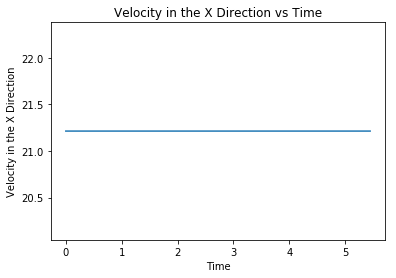

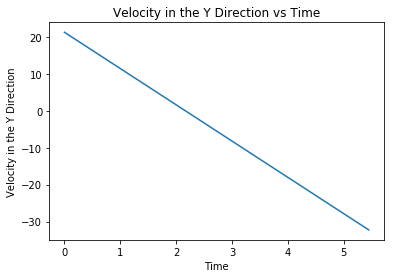

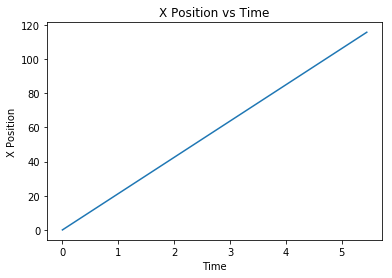

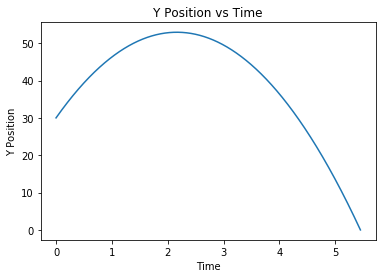

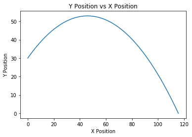

```python
import numpy as np
import matplotlib.pyplot as plt

# (a) Define some helpful variables:
#     (dt - time step, g - acceleration due to gravity)
dt = 0.001    # s
g  = -9.81    # m/s^2


#(b) Choose some initial conditions for position and velocity.
#    (angle - launch angle, v - launch speed, h - launch height)
angle = 45    # degrees
v     = 30    # m/s
h     = 30    # m

# (c) Initialize lists for time, x, y, vx , and vy
time = [0]    # s
x    = [0]    # m
y    = [h]    # m
vx   = [v * np.cos(np.radians(angle))] # m/s
vy   = [v * np.sin(np.radians(angle))] # m/s

# (d) Construct a while loop to iterate over time and calculate future values
#     of position and velocity using equations (6.7) and (6.8).
while (y[-1] > 0.0 or vy[-1] > 0.0):
    x    .append(x[-1] + vx[-1] * dt)
    y    .append(y[-1] + vy[-1] * dt)
    vx   .append(vx[-1])
    vy   .append(vy[-1] + g * dt)
    time .append(time[-1] + dt)

# box up the plotting code into a function so that we can reuse it.
def plot_nice(y , y_name,  x, x_name):
    plt.title(y_name + ' vs ' + x_name)
    plt.xlabel(x_name)
    plt.ylabel(y_name)
    plt.plot(x, y)
    plt.show()

# (e) Plot vx and vy vs time.
plot_nice(vx,"Velocity in the X Direction", time,"Time")
plot_nice(vy,"Velocity in the Y Direction", time,"Time")

# (f) Plot x and y vs time..
plot_nice(x,"X Position", time,"Time")
plot_nice(y,"Y Position", time,"Time")

# (g) Plot y vs x. This is called a trajectory plot.
plot_nice(y,"Y Position", x,"X Position")
```

### P6.3 (g) i

Use this plot to predict the landing location of a particle for at least three different launch conditions. Place a target at that location to verify that your code is working. You need to hit a target located both above and below the launch point.

```
We used the same cannon from last week with a 3.615 m/s speed (2 clicks), with the cannon's initial height of 0.265m off the ground.
```

> **Trial 1:** *Target Below Cannon* (angle: $60^\circ$, target height: 0 m, target distance: 1.31 m): *we hit the target*

> **Trial 2:** *Target Above Cannon* (angle: $75^\circ$, target height: 0.765 m, target distance: 0.50 m): *we hit the target*

[output not shown]

### P6.3 (g) ii

Change the step size $dt$ , and comment on the accuracy of the prediction as you vary $dt$.

> As we change `dt` we get a more precise prediction, becuase the intervals have less distance from each other (and thus less error)

# Take home thoughts

> This was a pretty cool lab. Of course, my favorite part was using Python. I did a similar lab in PH 121. It's satisfying when everything just works. Euler's Method is simple, but extremely powerful. Especially with machines that can run 3 million instructions per second, we are no longer as limited by large problems that were impossible to the older mathemticians.

# Sign off

- Kyle West
- Landon Lewis